# Introducing cricket package yorkr: Part 1- Beaten by sheer pace!

Tinniam V Ganesh

March 22, 2016

*“We need to regard statistical intuition with proper suspicion and replace impression formation by computation wherever possible”*

*“We are pattern seekers, believers in a coherent world”*

*“The hot hand is entirely in the eyes of the beholders, who are consistently”* *“too quick to perceive order and causality in randomeness. The hot hand is a”* *“massive and widespread cognitive illusion”*

```
                   "Thinking, Fast and Slow - Daniel Kahneman"
```

## **Introduction**

*Yorker (noun) :A yorker is a bowling delivery in cricket, that pitches at or around the batsman;s toes. Also known as ‘toe crusher’* My package ‘yorkr’ is now available on CRAN. This package is based on data from [Cricsheet](http://cricsheet.org/). Cricsheet has the data of ODIs, Test, Twenty20 and IPL matches as yaml files. The yorkr package provides functions to convert the yaml files to more easily R consumable entities, namely dataframes. In fact all ODI matches have already been converted and are available for use at yorkrData. More details below.

### 1. First things first

1. yorkr currently has a total 63 functions as of now. I have intentionally avoided abbreviating function names by dropping vowels, as is the usual practice in coding, because the resulting abbreviated names created would be very difficult to remember, and use. So instead of naming a function as *tmBmenPrtshpOppnAllMtches()*, I have used the longer form for e.g. *teamBatsmenPartnershipOppnAllmatches()*, which is much clearer.

The longer form will be more intuitive. Moreover RStudio prompts the the different functions which have the same prefix and one does not need to type in the entire function name.

2. The package yorkr has 4 classes of functions
- Class 1- Team performances in a match
- Class 2- Team performances in all matches against a single oppostion (e.g. all matches of India vs Australia or all matches of England vs Pakistan etc.)
- Class 3- Team performance in all matches against all Opposition (India vs All,Pakistan vs All etc.)
- Class 4- Individual performances of batsmen and bowlers

In this post I will be looking into Class 1 functions, namely the performances of opposing teams in a single match

The list of functions are

1. teamBattingScorecardMatch()
2. teamBatsmenPartnershipMatch()
3. teamBatsmenVsBowlersMatch()
4. teamBowlingScorecardMatch()
5. teamBowlingWicketKindMatch()
6. teamBowlingWicketRunsMatch()
7. teamBowlingWicketRunsMatch()
8. teamBowlingWicketMatch()
9. teamBowlersVsBatsmenMatch()
10. matchWormGraph()

### 2. Install the package from CRAN

```r
install.packages("yorkr_0.0.2.tar.gz",repos = NULL, type="source")
library(yorkr)
rm(list=ls())
```

*Note: In the above statement I install from the tarball (yorkr_0.0.2.tar.gz) since the package has yet to propagate to all servers. You should be able to directly install from CRAN using install.packages(“yorkr) in about 24 hours time.

### 3. Convert and save yaml file to dataframe

```r
convertYaml2RDataframe("225171.yaml","./source","./data")
```

```
## [1] "./source/225171.yaml"
## [1] "first loop"
## [1] "second loop"
```

```r
setwd("./data")
dir()
```

```
## [1] "Australia-India-2012-02-12.RData"
## [2] "Bangladesh-Zimbabwe-2009-10-27.RData"
## [3] "convertedFiles.txt"
## [4] "England-New Zealand-2007-01-30.RData"
## [5] "Ireland-England-2006-06-13.RData"
## [6] "Pakistan-South Africa-2013-11-08.RData"
## [7] "Sri Lanka-West Indies-2011-02-06.RData"
```

```r
setwd("..")
```

### 4. Convert and save all yaml files to dataframes

This function will convert all yaml files from a source directory to dataframes and save it in the target directory with the names as mentioned above.

```r
convertAllYaml2RDataframes("./source","./data")
```

```
## [1] 1
## i= 1   file= ./source/225171.yaml
## [1] "first loop"
## [1] "second loop"
## [1] 633  25
```

### 5. yorkrData - A Github repositiory

Cricsheet has ODI matches from 2006. There are a total of 1167 ODI matches(files) out of which 34 yaml files had format problems and were skipped. Incidentally I have already converted the 1133 yaml files in the ODI directory of Cricsheet to dataframes and saved then as RData. The rest of the yaml files ave already been converted to RData and are available for use. . All the converted RData files can be accessed from my Github link yorkrData under the folder ODI-matches

You can download the the zip of the files and use it directly in the functions as follows

**Note 1**: *The package in its current form is based on 50 over ODI macthes. The package will be enhanced to handle Tests, Twenty20,IPL matches later*

**Note 2**: *The link to the converted data frames have been provided above. The dataframes are around 600 rows x 25 columns. In this post I have created 10 functions that analyze team performances in a match. However you are free to slice and dice the dataframe in any way you like. If you do come up with interesting analyses, please do attribute the source of the data to Cricsheet, and my package yorkr and my blog. I would appreciate it if you could send me a note. .*

### 6. Load the match data as dataframes

As mentioned above in this post I will using the functions from Class 1. For this post I will be using the match data from 5 random matches between 10 different opposing teams/countries. For this I will directly use the converted RData files rather than getting the data through the getMatchDetails()

With the RData we can load the data in 2 ways

#### A. With getMatchDetails()

1. With getMatchDetails() using the 2 teams and the date on which the match occured

```r
aus_ind <- getMatchDetails("Australia","India","2012-02-12",dir="./data")
```

or ####B.Directly load RData into your code. The match details will be loaded into a dataframe called **’overs**’ which you can assign to a suitable name as below

The randomly selected matches are

#### Directly load RData from file

```r
load("./data/Australia-India-2012-02-12.RData")
aus_ind <- overs
load("./data/England-New Zealand-2007-01-30.RData")
eng_nz <- overs
load("./data/Pakistan-South Africa-2013-11-08.RData")
pak_sa <- overs
load("./data/Sri Lanka-West Indies-2011-02-06.RData")
sl_wi<- overs
load("./data/Bangladesh-Zimbabwe-2009-10-27.RData")
ban_zim <- overs
```

### 7. Team batting scorecard

```r
teamBattingScorecardMatch(aus_ind,'India')
```

```
## Total= 258
```

```
## Source: local data frame [8 x 5]
##
##     batsman ballsPlayed fours sixes  runs
##      (fctr)       (int) (dbl) (dbl) (dbl)
## 1 G Gambhir         110     7     0    92
## 2  V Sehwag          20     3     0    20
## 3   V Kohli          28     1     0    18
## 4 RG Sharma          41     1     1    33
## 5  SK Raina          30     3     1    38
## 6  MS Dhoni          57     0     1    44
## 7 RA Jadeja           8     0     0    12
## 8  R Ashwin           2     0     0     1
```

```r
teamBattingScorecardMatch(aus_ind,'Australia')
```

```
## Total= 260
```

```
## Source: local data frame [9 x 5]
##
##        batsman ballsPlayed fours sixes  runs
##         (fctr)       (int) (dbl) (dbl) (dbl)
## 1    DA Warner          23     2     0    18
## 2   RT Ponting          13     1     0     6
## 3    MJ Clarke          43     5     0    38
## 4   PJ Forrest          83     5     2    66
## 5    DJ Hussey          76     5     0    72
## 6 DT Christian          36     2     0    39
## 7      MS Wade          17     1     0    16
## 8    RJ Harris           2     0     0     2
## 9     CJ McKay           3     0     0     3
```

```r
teamBattingScorecardMatch(pak_sa,'South Africa')
```

```
## Total= 256
```

```
## Source: local data frame [7 x 5]
##
##          batsman ballsPlayed fours sixes  runs
##           (fctr)       (int) (dbl) (dbl) (dbl)
## 1      Q de Kock         132     9     1   112
## 2        HM Amla          50     6     0    46
## 3   F du Plessis          21     1     0    10
## 4 AB de Villiers          40     2     0    30
## 5      DA Miller           9     0     0     5
## 6      JP Duminy          20     1     1    25
## 7      R McLaren          21     3     1    28
```

```r
teamBattingScorecardMatch(sl_wi,'Sri Lanka')
```

```
## Total= 261
```

```
## Source: local data frame [10 x 5]
##
##             batsman ballsPlayed fours sixes  runs
##              (fctr)       (int) (dbl) (dbl) (dbl)
## 1       WU Tharanga          50     5     0    39
## 2        TM Dilshan          27     2     1    30
## 3     KC Sangakkara         103     4     1    75
## 4  DPMD Jayawardene          52     2     0    44
## 5     CK Kapugedera          17     0     0    17
## 6    TT Samaraweera           7     0     0     4
## 7       NLTC Perera           8     0     0     6
## 8        AD Mathews          22     1     1    36
## 9      HMRKB Herath           4     0     0     2
## 10       BAW Mendis           6     1     0     8
```

### 8. Plot the team batting partnerships

The functions below plot the team batting partnetship in the match **Note**: Many of the plots include an additional parameters plot which is either TRUE or FALSE. The default value is plot=TRUE. When plot=TRUE the plot will be displayed. When plot=FALSE the data frame will be returned to the user. The user can use this to create an interactive chary using one of th epackages like rcharts, ggvis,googleVis or plotly.

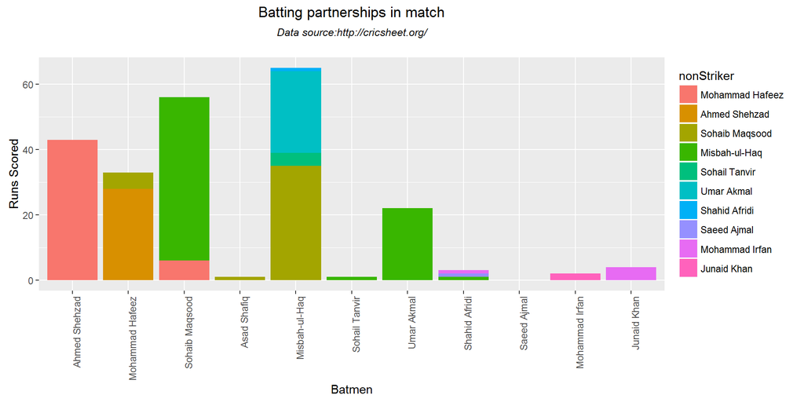

```r
teamBatsmenPartnershipMatch(pak_sa,"Pakistan")
```

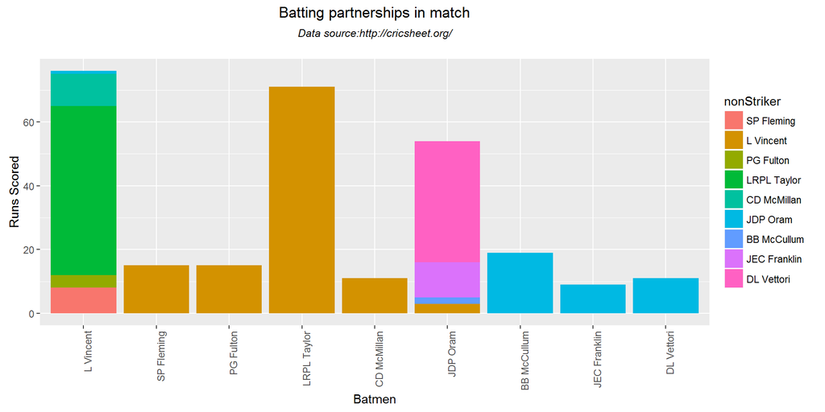

```r
teamBatsmenPartnershipMatch(eng_nz,"New Zealand",plot=TRUE)
```

```r
m <-teamBatsmenPartnershipMatch(ban_zim,"Bangladesh",plot=FALSE)
m
```

```
##              batsman        nonStriker runs
## 1        Tamim Iqbal   Junaid Siddique    0
## 2        Tamim Iqbal Mohammad Ashraful    5
## 3    Junaid Siddique       Tamim Iqbal    0
## 4  Mohammad Ashraful       Tamim Iqbal    0
## 5  Mohammad Ashraful     Raqibul Hasan   20
## 6      Raqibul Hasan Mohammad Ashraful   13
## 7      Raqibul Hasan   Shakib Al Hasan    3
## 8    Shakib Al Hasan     Raqibul Hasan   12
## 9    Shakib Al Hasan   Mushfiqur Rahim    1
## 10   Mushfiqur Rahim   Shakib Al Hasan    1
## 11   Mushfiqur Rahim       Naeem Islam   30
## 12   Mushfiqur Rahim      Abdur Razzak    6
## 13   Mushfiqur Rahim      Dolar Mahmud   11
## 14   Mushfiqur Rahim     Rubel Hossain    8
## 15       Mahmudullah   Mushfiqur Rahim    4
## 16       Naeem Islam   Mushfiqur Rahim   21
## 17      Abdur Razzak   Mushfiqur Rahim    3
## 18      Dolar Mahmud   Mushfiqur Rahim   41
```

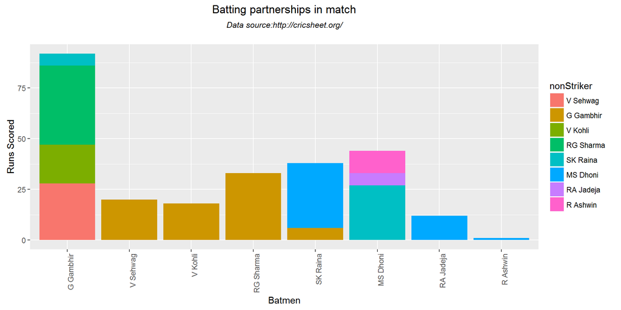

```r
teamBatsmenPartnershipMatch(aus_ind,"India",plot=TRUE)
```

### 9. Batsmen vs Bowler

The function below computes and plots the performances of the batsmen vs the bowlers. As before the plot parameter can be set to TRUE or FALSE. By default it is plot=TRUE

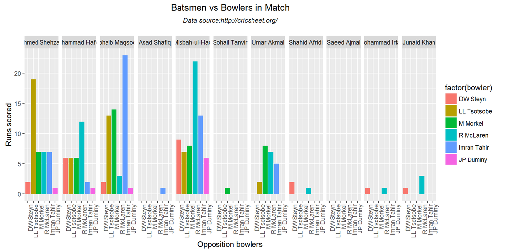

```r
teamBatsmenVsBowlersMatch(pak_sa,'Pakistan',plot=TRUE)
```

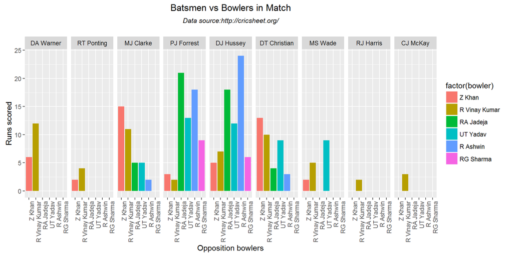

```r
teamBatsmenVsBowlersMatch(aus_ind,'Australia',plot=TRUE)
```

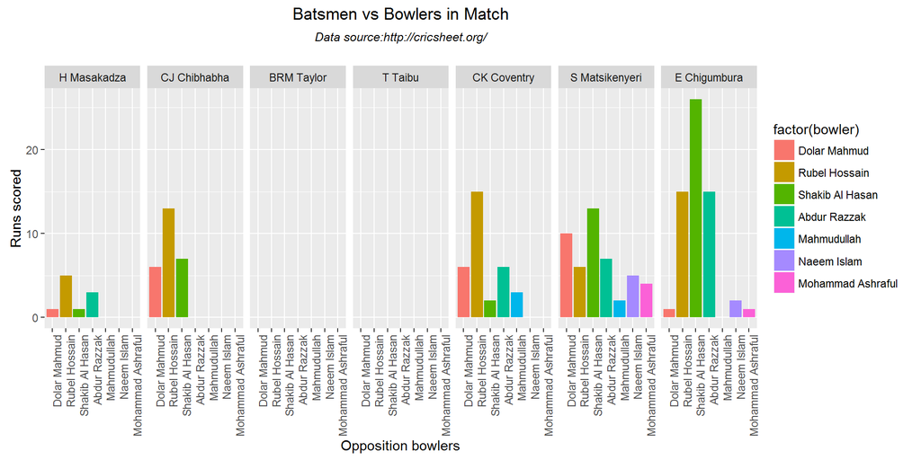

```r
teamBatsmenVsBowlersMatch(ban_zim,'Zimbabwe',plot=TRUE)
```

```r
m <- teamBatsmenVsBowlersMatch(sl_wi,'West Indies',plot=FALSE)
m
```

```
## Source: local data frame [35 x 3]
## Groups: batsman [?]
##
##      batsman        bowler runsConceded
##       (fctr)        (fctr)        (dbl)
## 1   CH Gayle  CRD Fernando            0
## 2   DM Bravo  CRD Fernando           15
## 3   DM Bravo   NLTC Perera           21
## 4   DM Bravo    AD Mathews           10
## 5   DM Bravo    BAW Mendis           11
## 6   DM Bravo CK Kapugedera            1
## 7   DM Bravo    TM Dilshan            5
## 8   DM Bravo  HMRKB Herath           16
## 9  AB Barath   NLTC Perera            0
## 10 RR Sarwan  CRD Fernando            6
## ..       ...           ...          ...
```

### 10. Bowling Scorecard

This function provides the bowling performance, the number of overs bowled, maidens, runs conceded and wickets taken for each match

```r
teamBowlingScorecardMatch(eng_nz,'England')
```

```
## Source: local data frame [6 x 5]
##
##           bowler overs maidens  runs wickets
##           (fctr) (int)   (int) (dbl)   (dbl)
## 1    LE Plunkett     9       0    54       3
## 2    CT Tremlett    10       0    72       1
## 3     A Flintoff    10       0    66       0
## 4     MS Panesar    10       2    35       2
## 5  JWM Dalrymple     5       0    43       0
## 6 PD Collingwood     6       0    36       1
```

```r
teamBowlingScorecardMatch(eng_nz,'New Zealand')
```

```
## Source: local data frame [6 x 5]
##
##         bowler overs maidens  runs wickets
##         (fctr) (int)   (int) (dbl)   (dbl)
## 1 JEC Franklin     8       1    45       1
## 2      SE Bond    10       0    58       1
## 3     JDP Oram     5       0    23       0
## 4     JS Patel    10       0    53       1
## 5   DL Vettori    10       0    40       3
## 6  CD McMillan     7       1    38       2
```

```r
teamBowlingScorecardMatch(aus_ind,'Australia')
```

```
## Source: local data frame [6 x 5]
##
##         bowler overs maidens  runs wickets
##         (fctr) (int)   (int) (dbl)   (dbl)
## 1    RJ Harris    10       0    57       1
## 2     MA Starc     8       0    49       0
## 3     CJ McKay    10       1    53       3
## 4 DT Christian    10       0    45       0
## 5    DJ Hussey     3       0    13       0
## 6   XJ Doherty     9       0    51       2
```

### 11. Wicket Kind

The plots below provide the bowling kind of wicket taken by the bowler (caught, bowled, lbw etc.)

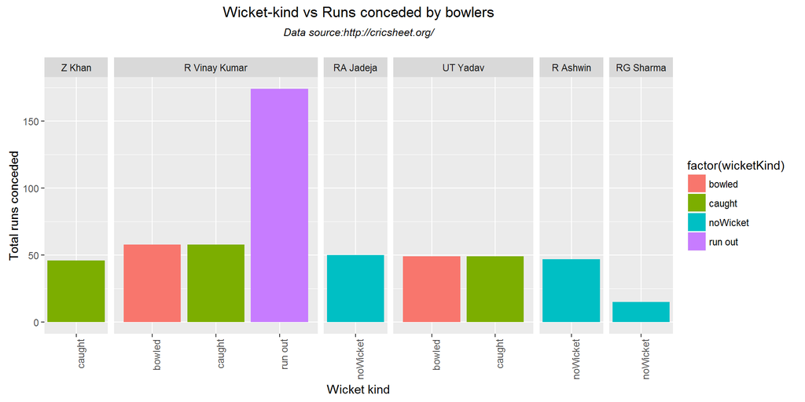

```r
teamBowlingWicketKindMatch(aus_ind,"India")
```

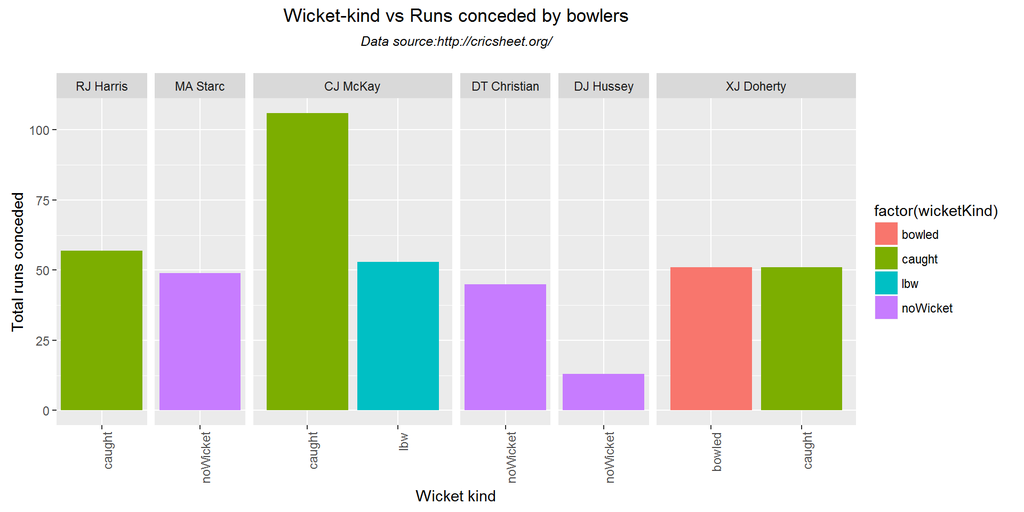

```r
teamBowlingWicketKindMatch(aus_ind,"Australia")
```

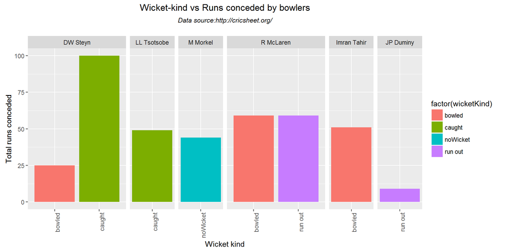

```r
teamBowlingWicketKindMatch(pak_sa,"South Africa")
```

```r
m <-teamBowlingWicketKindMatch(sl_wi,"Sri Lanka",plot=FALSE)
m
```

```
##           bowler wicketKind wicketPlayerOut runs
## 1   CRD Fernando     bowled        CH Gayle   45
## 2    NLTC Perera     caught       AB Barath   36
## 3   HMRKB Herath        lbw       RR Sarwan   54
## 4     BAW Mendis     caught   S Chanderpaul   46
## 5    NLTC Perera        lbw        DM Bravo   36
## 6    NLTC Perera     caught       DJG Sammy   36
## 7   CRD Fernando     caught        DJ Bravo   45
## 8     BAW Mendis     caught       NO Miller   46
## 9     BAW Mendis     caught        CS Baugh   46
## 10    BAW Mendis     caught         SJ Benn   46
## 11    AD Mathews   noWicket        noWicket   33
## 12 CK Kapugedera   noWicket        noWicket    7
## 13    TM Dilshan   noWicket        noWicket   25
```

### 12. wicket vs Runs conceded

The plots below provide the wickets taken and the runs conceded by the bowler in the match

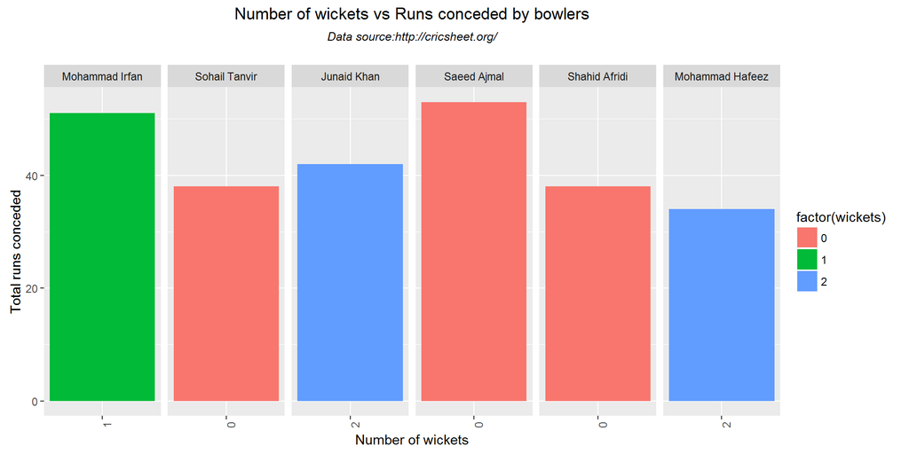

```r
teamBowlingWicketRunsMatch(pak_sa,"Pakistan")
```

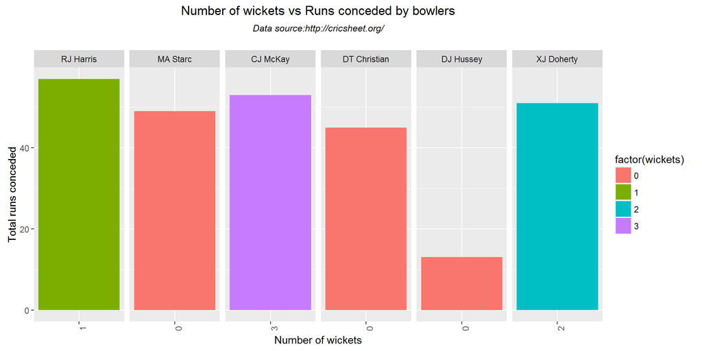

```r
teamBowlingWicketRunsMatch(aus_ind,"Australia")
```

```r
m <-teamBowlingWicketRunsMatch(sl_wi,"West Indies",plot=FALSE)
m
```

```
## Source: local data frame [6 x 5]
##
##      bowler overs maidens  runs wickets
##      (fctr) (int)   (int) (dbl)   (chr)
## 1 R Rampaul     5       0    44       1
## 2 DJG Sammy    10       1    61       1
## 3  DJ Bravo    10       0    58       3
## 4  CH Gayle    10       0    34       0
## 5   SJ Benn    10       1    38       4
## 6 NO Miller     5       0    35       0
```

### 13. Wickets taken by bowler

The plots provide the wickets taken by the bowler

```r
m <-teamBowlingWicketMatch(eng_nz,'England',plot=FALSE)
m
```

```
##           bowler wicketKind wicketPlayerOut runs
## 1    LE Plunkett        lbw      SP Fleming   54
## 2    LE Plunkett     caught       PG Fulton   54
## 3 PD Collingwood     caught     LRPL Taylor   36
## 4     MS Panesar    stumped     CD McMillan   35
## 5    LE Plunkett     caught       L Vincent   54
## 6     MS Panesar     caught     BB McCullum   35
## 7    CT Tremlett     caught    JEC Franklin   72
## 8     A Flintoff   noWicket        noWicket   66
## 9  JWM Dalrymple   noWicket        noWicket   43
```

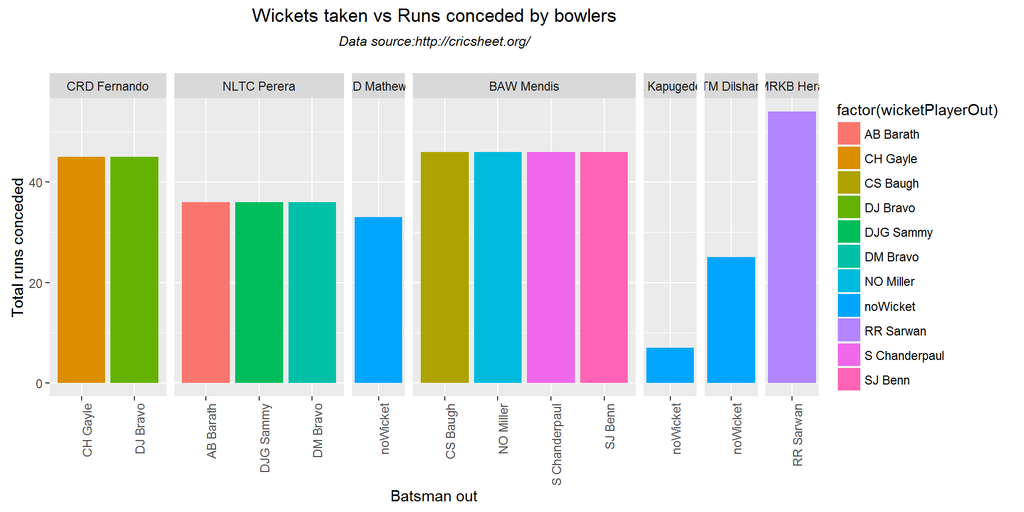

```r
teamBowlingWicketMatch(sl_wi,"Sri Lanka")
```

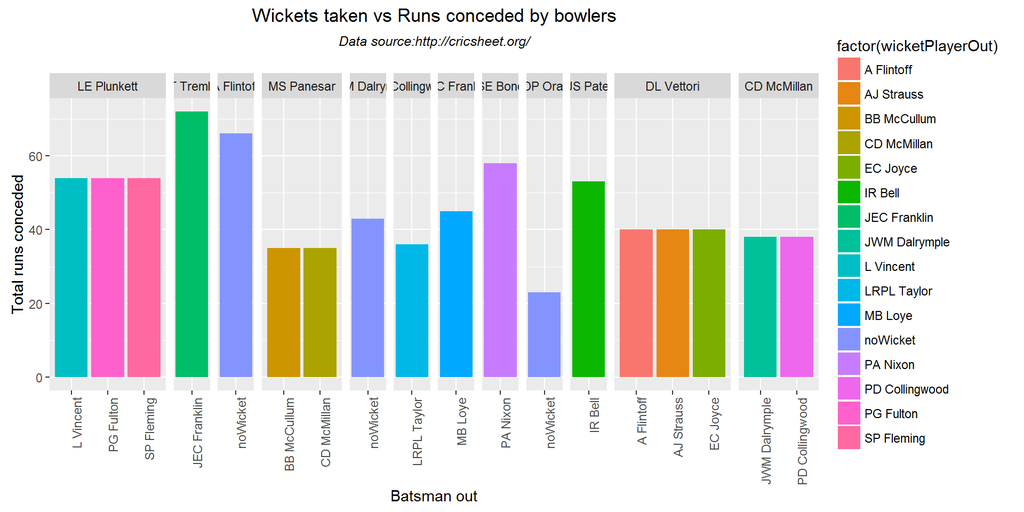

```r
teamBowlingWicketMatch(eng_nz,"New Zealan")
```

### 14. Bowler Vs Batsmen

The functions compute and display how the different bowlers of the country performed against the batting opposition.

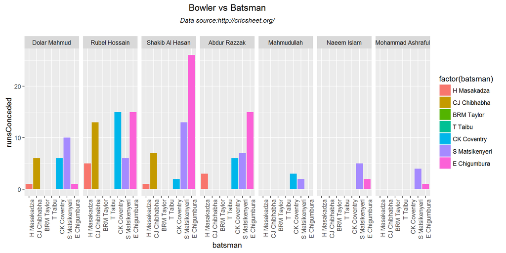

```r
teamBowlersVsBatsmenMatch(ban_zim,"Bangladesh")
```

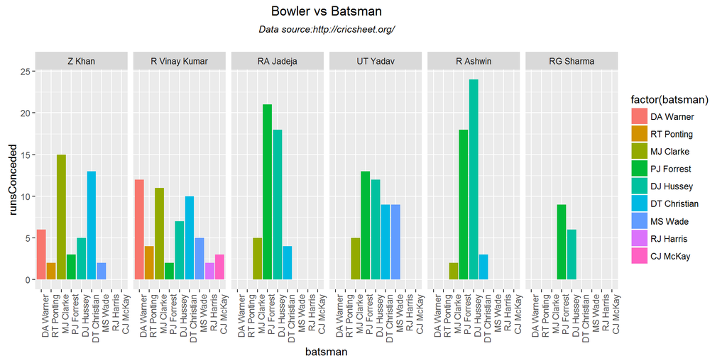

```r
teamBowlersVsBatsmenMatch(aus_ind,"India")
```

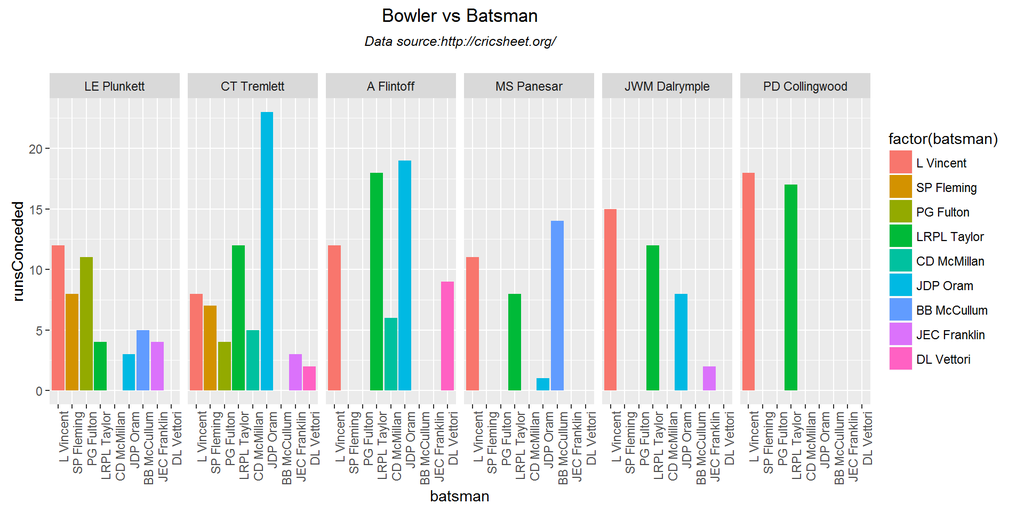

```r
teamBowlersVsBatsmenMatch(eng_nz,"England")
```

```r
m <- teamBowlersVsBatsmenMatch(pak_sa,"Pakistan",plot=FALSE)
m
```

```
## Source: local data frame [30 x 3]
## Groups: bowler [?]
##
##            bowler        batsman runsConceded
##            (fctr)         (fctr)        (dbl)
## 1  Mohammad Irfan      Q de Kock           25
## 2  Mohammad Irfan        HM Amla           17
## 3  Mohammad Irfan   F du Plessis            0
## 4  Mohammad Irfan AB de Villiers            9
## 5   Sohail Tanvir      Q de Kock           11
## 6   Sohail Tanvir        HM Amla            6
## 7   Sohail Tanvir      JP Duminy            9
## 8   Sohail Tanvir      R McLaren           12
## 9     Junaid Khan      Q de Kock           24
## 10    Junaid Khan        HM Amla            6
## ..            ...            ...          ...
```

### 15. Match worm graph

The plots below provide the match worm graph for the matches

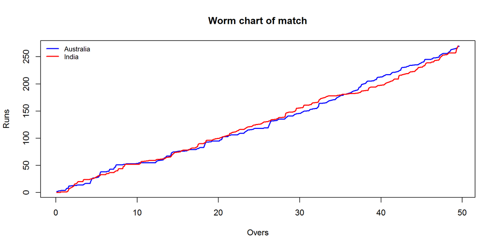

```r
matchWormGraph(aus_ind,'Australia',"India")
```

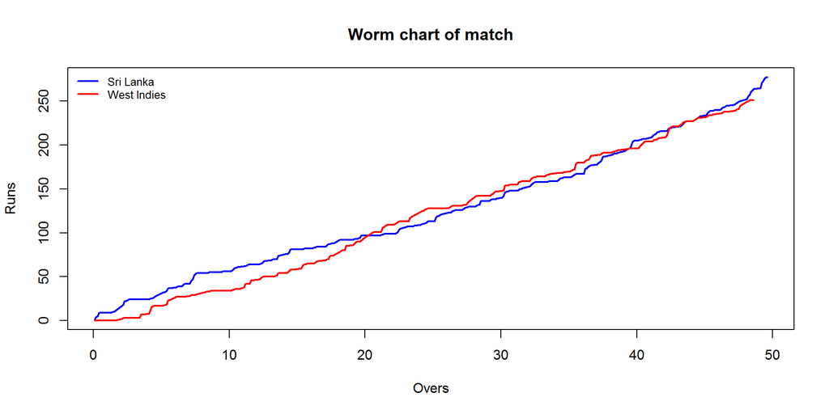

```r
matchWormGraph(sl_wi,'Sri Lanka',"West Indies")
```